# Trajectory of Taxis

Here we'll explore taxi trip data collected from Beijing in 2008. It's described in

https://www.microsoft.com/en-us/research/publication/t-drive-trajectory-data-sample/

## First things first

It turns out that there are **missing links** to the data files from that website. For convenience, I've **repacked** them in the current directory (t-drive-sample-part1.zip, t-drive-sample-part2.zip). To **run** the notebook (taxis.ipynb), you'll need to unzip those files.

The missing urls were easy to infer. The files are labeled ranging from 01.zip to 014.zip starting at the url: https://www.microsoft.com/en-us/research/wp-content/uploads/2016/02/01.zip

Using all the available data gives a better view of the details. For example here's a view of Beijing via the taxi data. The code to reproduce this is below.

[figure not shown]

Ok, let's get started.

```python
from __future__ import division # python 2.7
import pandas as pd
import numpy as np
import matplotlib.pylab as plt
plt.style.use('ggplot')
import os
import glob
import datashader as ds
import datashader.transfer_functions as tf
```

## Create the dataframe

```python
# Read files into a dataframe

# FYI this takes a minute...

# Assuming file directories are placed in directory ./t-drive-sample/
path = r'./t-drive-sample-part*/0*/'
taxi_files = glob.glob(os.path.join(path, "*.txt"))
column_names = ['taxi_id', 'date_time', 'longitude', 'latitude']
df_master = pd.concat(pd.read_csv(f, names=column_names) for f in taxi_files)  # glue all data into the dataframe

df_master['date_time'] = pd.to_datetime(df_master.date_time) # Correct the type in date_time column
```

```python
df = df_master.copy() # Allows you to 'restart' the worksheet without waiting to recreate dataframe
```

# (1.A) Graph time intervals

## A look at the data

After browsing files the directory 01/, I noticed there is a variety of sampling time rates. Here's two examples where the sampling rate looks like ~ 5 **seconds** versus ~ 5 **minutes**.

```python
df[df.taxi_id == 1131].head() # has 5 second intervals
```

|  | taxi_id | date_time | longitude | latitude |
| --- | --- | --- | --- | --- |
| 0 | 1131.0 | 2008-02-02 13:30:49 | 116.45804 | 39.86973 |
| 1 | 1131.0 | 2008-02-02 13:30:54 | 116.45828 | 39.86970 |
| 2 | 1131.0 | 2008-02-02 13:30:59 | 116.45847 | 39.86964 |
| 3 | 1131.0 | 2008-02-02 13:31:04 | 116.45852 | 39.86954 |
| 4 | 1131.0 | 2008-02-02 13:31:09 | 116.45851 | 39.86955 |

```python
df[df.taxi_id == 2237].head() # has 5 minute intervals
```

|  | taxi_id | date_time | longitude | latitude |
| --- | --- | --- | --- | --- |
| 0 | 2237.0 | 2008-02-02 13:47:30 | 0.00000 | 0.00000 |
| 1 | 2237.0 | 2008-02-02 13:52:22 | 116.30368 | 39.97505 |
| 2 | 2237.0 | 2008-02-02 13:57:22 | 116.30113 | 39.99632 |
| 3 | 2237.0 | 2008-02-02 14:12:22 | 116.34702 | 39.98575 |
| 4 | 2237.0 | 2008-02-02 14:25:01 | 116.34909 | 39.93935 |

## Sampling rates

In the following plot each curve represents the sample times from an individual taxi's file. This reflects the fact that the taxis were sampled at a variety of rates. There two dominant dark lines here; one is diagonal and one is nearly vertical. These reflect the most common sampling rates, which are also reflected in the time intervals histogram below.

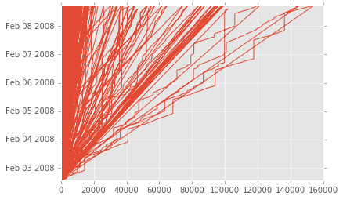

```python
plt.plot(df['date_time'])
plt.show()
```

## Distribution of time intervals

Next let's look at the distribution of time intervals. For comparison, here are the graphs we'd like to reproduce. ([source](http://research.microsoft.com/pubs/152883/User_guide_T-drive.pdf))

[figure not shown]

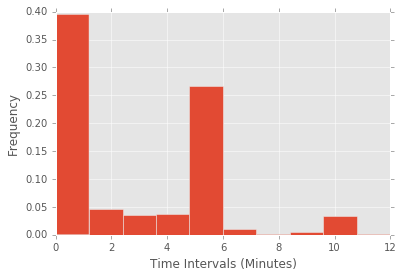

```python
# Calculate the intervals in minutes.
df_time_diffs = df['date_time'].diff().astype('timedelta64[m]')

# Histogram
df_time_hist = df_time_diffs.hist(normed=True, range=(0,12))
df_time_hist.set_ylabel("Frequency")
df_time_hist.set_xlabel("Time Intervals (Minutes)")
plt.show()
```

Interestingly, the same shape appears at two levels: minutes & seconds. This reflects the choice of common intervals 1sec, 5sec, 1min, 5min. To see this, you can run the code after swapping *m* to *s* in *'timedelta64[m]'*.

# (1.B) Graph distance intervals.

## Calculate GPS distances

Next we'd like to compute incremental distances between GPS points. This dataset is large enough that ordinary python code might run too slow. There are a number of algorithms and tools for computing the distance between two GPS points. In fact, I tested several tools from python libraries like geopy (vincenty) and geographiclib (Geodesic.WGS84.Inverse). I found them to be far too slow to use (they'd take at least a day to finish!). Instead, I chose a simple numerical formula written in vectorized python (numpy) for speed.

```python
# Use numpy functions for the distance formula

def gps_dist(a, b, c, d):
    '''Compute the distance (in meters) between two gps locations. Input is assumed to be a = longitude, b = latitude, etc.'''
    r = 0.0174533  # 1 degree in radians
    return 2 * 6371000 * np.arcsin( np.sqrt( # https://en.wikipedia.org/wiki/Haversine_formula
        np.sin(r*(d - b)/2.0)**2 + np.cos(r*b) * np.cos(r*d) * np.sin(r*(c - a)/2.0)**2))
```

Next we'd like to reproduce Figure 1 (b).

[figure not shown]

To do this, compute the row by row distance intervals, and draw its histogram.

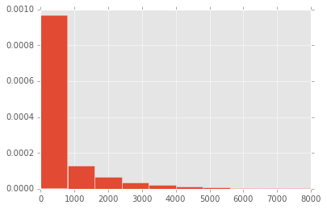

```python
df['dist'] = gps_dist(df.longitude,df.latitude, df.longitude.shift(),df.latitude.shift())  # shifted array
df.dist.hist(range=(0,8000), normed=True)
plt.show()
```

## Visualize the dataset

Finally, let's just take a look at the raw dataset. Here, it helps to ignore the craziest of outliers.

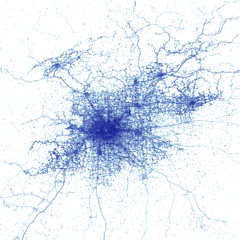

```python
_ = df[abs(df.longitude -116.5) <= 1]
_ = _[abs(_.latitude - 40.0) <= 1]
cvs = ds.Canvas(plot_width=400, plot_height=400)
agg = cvs.points(_,'longitude','latitude')
img = tf.shade(agg, cmap=['lightblue','darkblue'],how='log')
img
```

Now zooming in on Beijing.

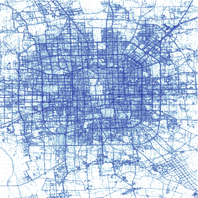

```python
_ = df[abs(df.longitude -116.39) <= 0.15]
_ = _[abs(_.latitude - 39.9) <= 0.15]
cvs = ds.Canvas(plot_width=400, plot_height=400)
agg = cvs.points(_,'longitude','latitude')
img = tf.shade(agg, cmap=['lightblue','darkblue'],how='log')
img
```